# Data Management

### Anxiety

**Please answer the following questions based on how you felt in the past 7 days.**

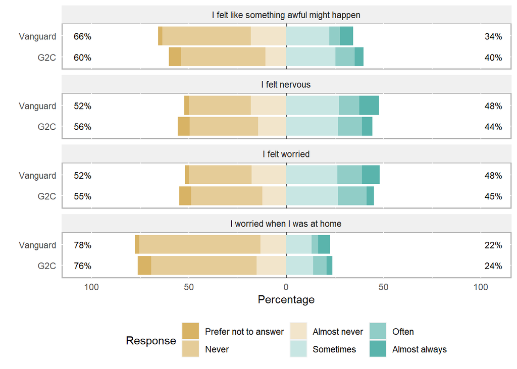

**Histogram of anxiety Scores (total of 4 variables, range:0-16): Vanguard vs. G2C**

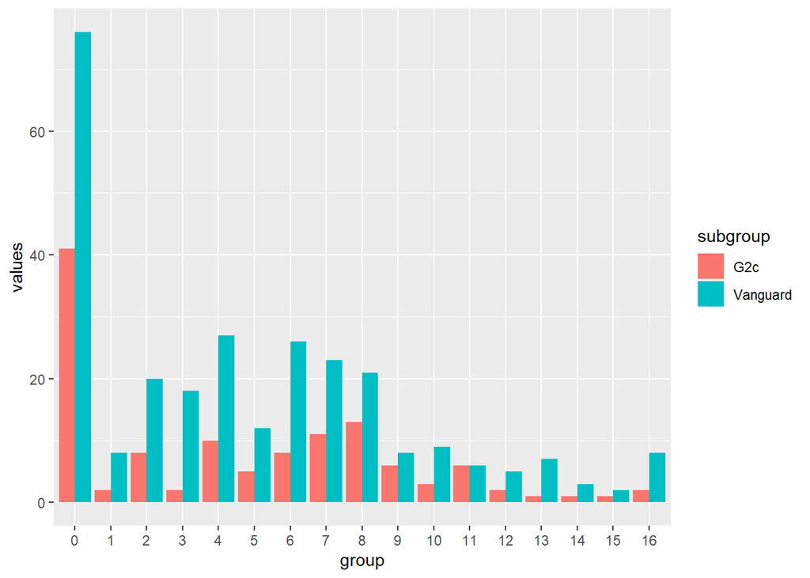

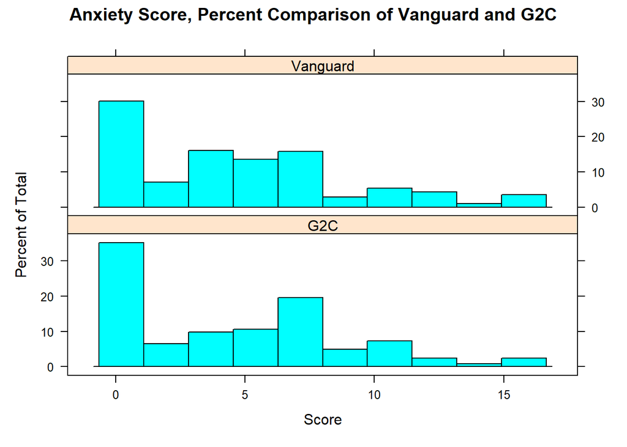

```
##
##  Wilcoxon rank sum test with continuity correction
##
## data:  anxiety_total_merged$anxiety_total_no_refused by anxiety_total_merged$study
## W = 16778, p-value = 0.8189
## alternative hypothesis: true location shift is not equal to 0
```

```
##
##  Welch Two Sample t-test
##
## data:  anxiety_total_merged$anxiety_total_no_refused by anxiety_total_merged$study
## t = -0.30148, df = 231.83, p-value = 0.7633
## alternative hypothesis: true difference in means between group G2C and group Vanguard is not equal to 0
## 95 percent confidence interval:
##  -1.0701506  0.7861151
## sample estimates:
##      mean in group G2C mean in group Vanguard
##               4.639344               4.781362
```

Anxiety Score comparison

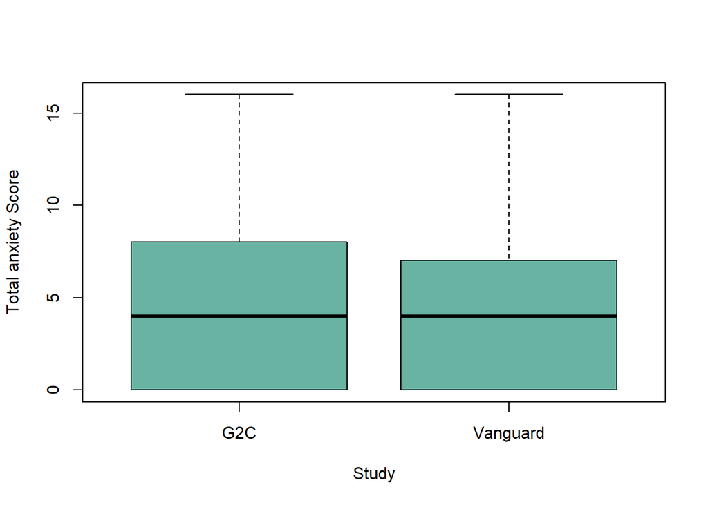

### PTSD/Trauma

**“Below is a list of problems that people sometimes have in response to a very stressful experience. Please read each problem carefully and then circle one of the numbers to the right to indicate how much you have been bothered by that problem in the past 30 days. In the past 30 days, how much were you bothered by:”**

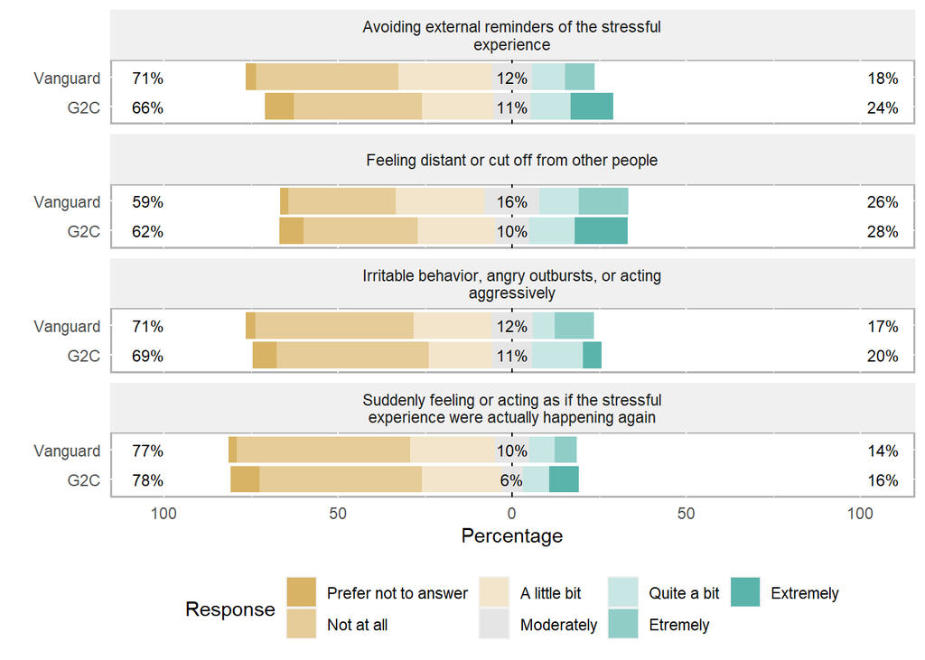

**Histogram of ptsd Scores (total of 4 variables, range:0-16): Vanguard vs. G2C**

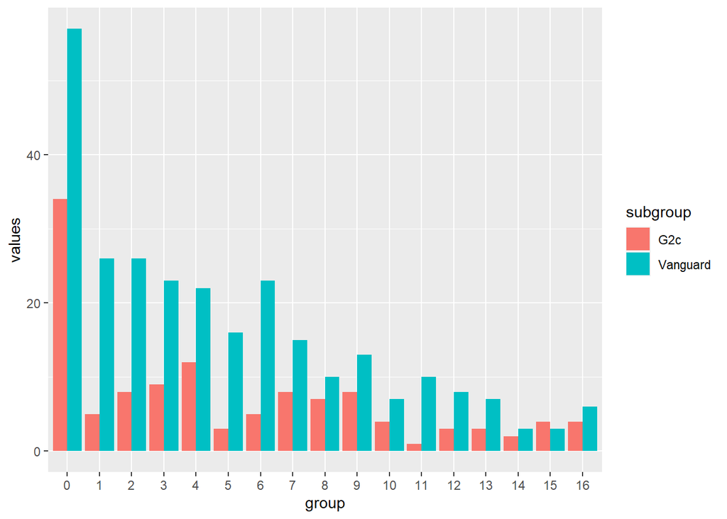

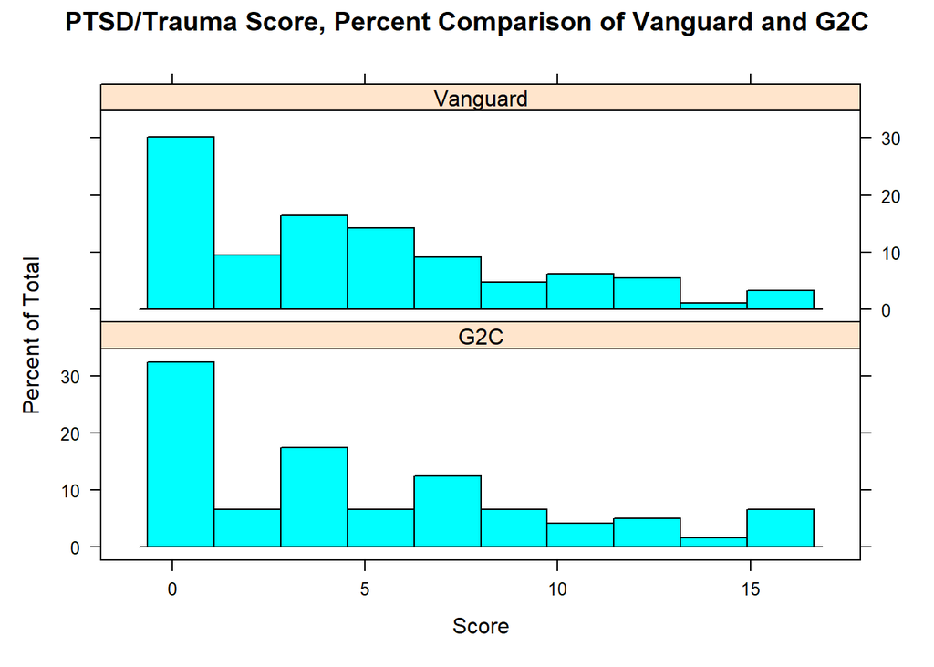

```
##
##  Wilcoxon rank sum test with continuity correction
##
## data:  ptsd_total_merged$ptsd_total_no_refused by ptsd_total_merged$study
## W = 16575, p-value = 0.943
## alternative hypothesis: true location shift is not equal to 0
```

```
##
##  Welch Two Sample t-test
##
## data:  ptsd_total_merged$ptsd_total_no_refused by ptsd_total_merged$study
## t = 0.54307, df = 206.37, p-value = 0.5877
## alternative hypothesis: true difference in means between group G2C and group Vanguard is not equal to 0
## 95 percent confidence interval:
##  -0.7352901  1.2943810
## sample estimates:
##      mean in group G2C mean in group Vanguard
##               5.025000               4.745455
```

PTSD Score comparison

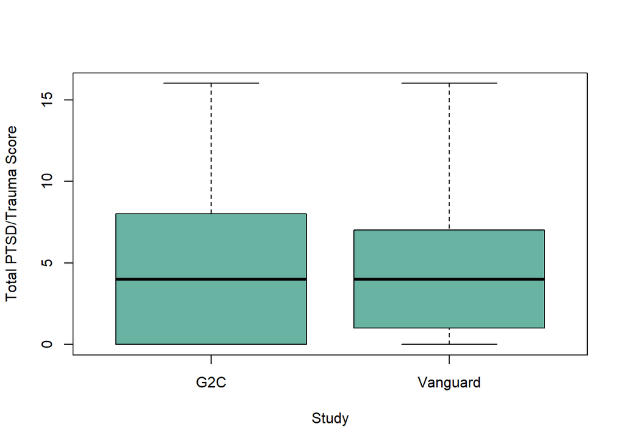

### Depression

**Please answer the following questions based on how you felt in the past 7 days.**

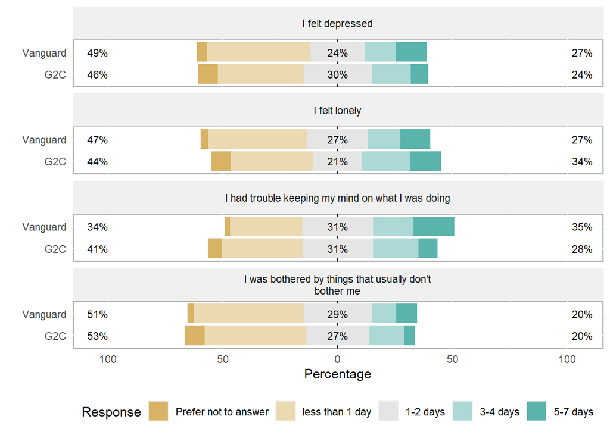

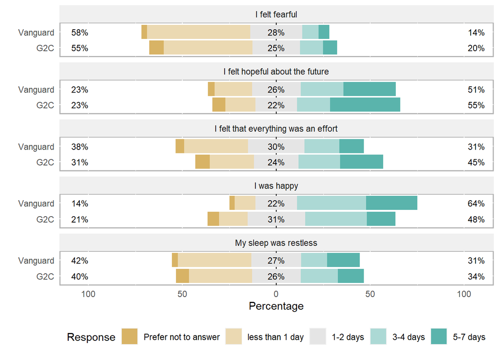

**Histogram of Depression Scores (total of 10 variables, range:0-30): Vanguard vs. G2C**

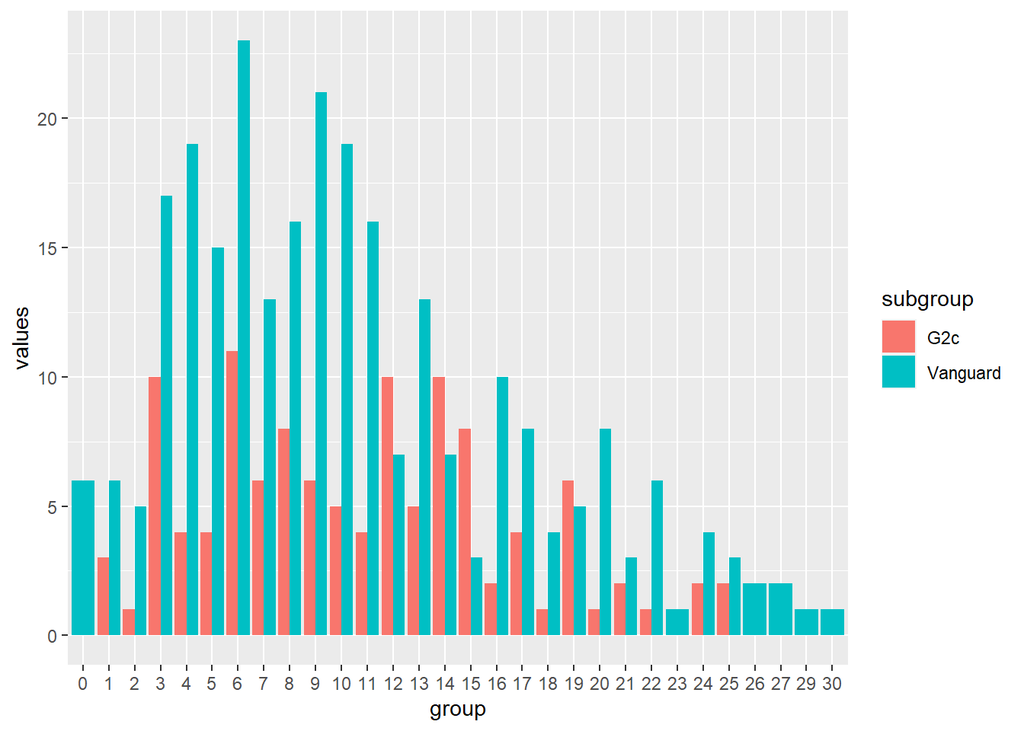

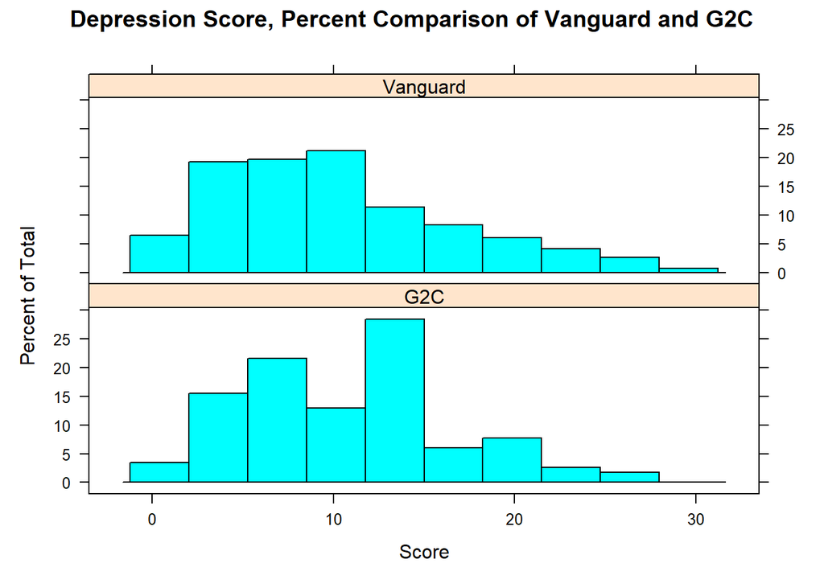

```
##
##  Wilcoxon rank sum test with continuity correction
##
## data:  depression_total_merged$depression_total_no_refused by depression_total_merged$study
## W = 16548, p-value = 0.2095
## alternative hypothesis: true location shift is not equal to 0
```

```
##
##  Welch Two Sample t-test
##
## data:  depression_total_merged$depression_total_no_refused by depression_total_merged$study
## t = 0.80302, df = 245.53, p-value = 0.4227
## alternative hypothesis: true difference in means between group G2C and group Vanguard is not equal to 0
## 95 percent confidence interval:
##  -0.7805066  1.8549580
## sample estimates:
##      mean in group G2C mean in group Vanguard
##               10.77586               10.23864
```

Depression score comparison

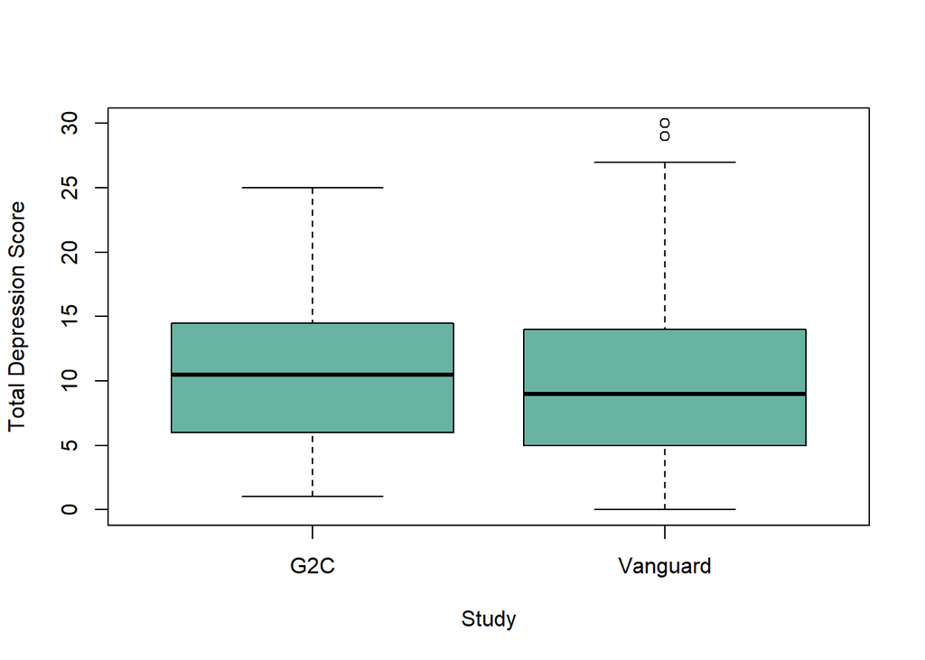

### Correlation Matrix

Correlation Matrix of G2C Food Security, Anxiety, PTSD, and Depression scores

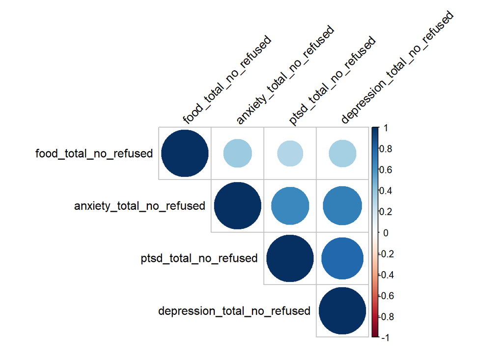

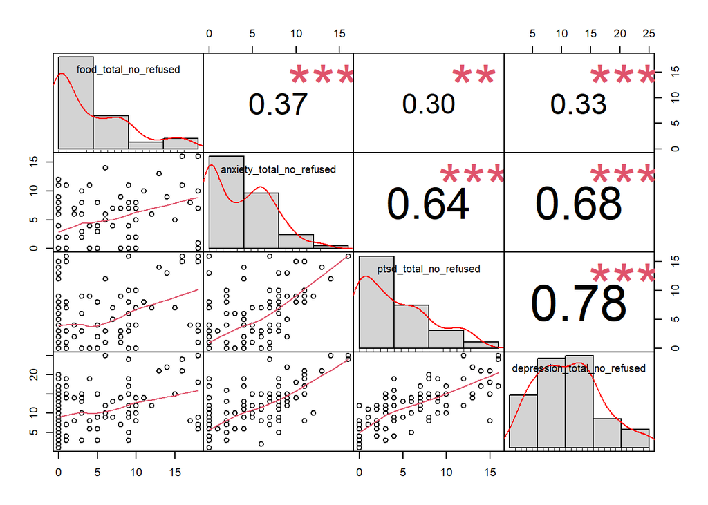

Correlation Matrix of VANGUARD Food Security, Anxiety, PTSD, and Depression scores.

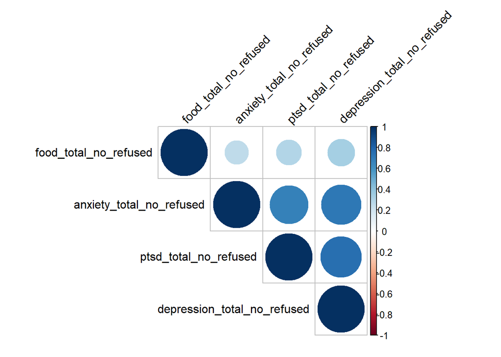

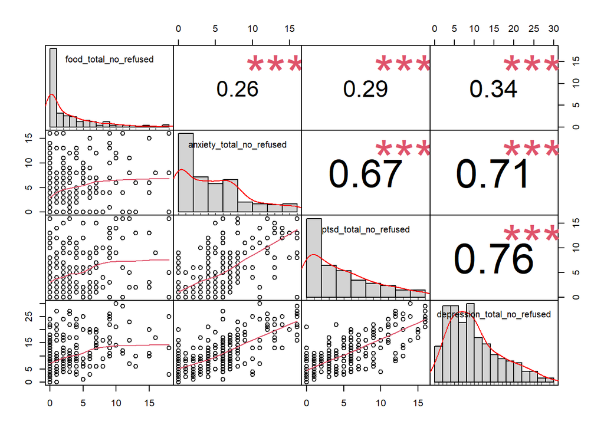

### Cross Tabs

Cross Tab - by Study and Food Security Flag

```
##
##
##    Cell Contents
## |-------------------------|
## |                       N |
## |           N / Row Total |
## |-------------------------|
##
##
## Total Observations in Table:  417
##
##
##              | Food Flag, >=2 (max: 18)
##        Study |         0 |         1 | Row Total |
## -------------|-----------|-----------|-----------|
##          G2C |        53 |        78 |       131 |
##              |      0.40 |      0.60 |      0.31 |
## -------------|-----------|-----------|-----------|
##     Vanguard |       139 |       147 |       286 |
##              |      0.49 |      0.51 |      0.69 |
## -------------|-----------|-----------|-----------|
## Column Total |       192 |       225 |       417 |
## -------------|-----------|-----------|-----------|
##
##
```

Cross Tab - by Study and Anxiety Flag

```
##
##
##    Cell Contents
## |-------------------------|
## |                       N |
## |           N / Row Total |
## |-------------------------|
##
##
## Total Observations in Table:  417
##
##
##              | Anxiety Flag, >=8 (max: 16)
##        Study |         0 |         1 | Row Total |
## -------------|-----------|-----------|-----------|
##          G2C |        87 |        44 |       131 |
##              |      0.66 |      0.34 |      0.31 |
## -------------|-----------|-----------|-----------|
##     Vanguard |       210 |        76 |       286 |
##              |      0.73 |      0.27 |      0.69 |
## -------------|-----------|-----------|-----------|
## Column Total |       297 |       120 |       417 |
## -------------|-----------|-----------|-----------|
##
##
```

Cross Tab - Study and PTSD Flag

```
##
##
##    Cell Contents
## |-------------------------|
## |                       N |
## |           N / Row Total |
## |-------------------------|
##
##
## Total Observations in Table:  417
##
##
##              | PTSD Flag, >=7 (max: 16)
##        Study |         0 |         1 | Row Total |
## -------------|-----------|-----------|-----------|
##          G2C |        76 |        55 |       131 |
##              |      0.58 |      0.42 |      0.31 |
## -------------|-----------|-----------|-----------|
##     Vanguard |       193 |        93 |       286 |
##              |      0.67 |      0.33 |      0.69 |
## -------------|-----------|-----------|-----------|
## Column Total |       269 |       148 |       417 |
## -------------|-----------|-----------|-----------|
##
##
```

Cross Tab - Study and Depression Flag

```
##
##
##    Cell Contents
## |-------------------------|
## |                       N |
## |           N / Row Total |
## |-------------------------|
##
##
## Total Observations in Table:  417
##
##
##              | Depression Flag, >=9 (max: 30)
##        Study |         0 |         1 | Row Total |
## -------------|-----------|-----------|-----------|
##          G2C |        47 |        84 |       131 |
##              |      0.36 |      0.64 |      0.31 |
## -------------|-----------|-----------|-----------|
##     Vanguard |       120 |       166 |       286 |
##              |      0.42 |      0.58 |      0.69 |
## -------------|-----------|-----------|-----------|
## Column Total |       167 |       250 |       417 |
## -------------|-----------|-----------|-----------|
##
##
```

### Food Insecurity

“The next set of questions will ask you about food in your household.  
How often…”

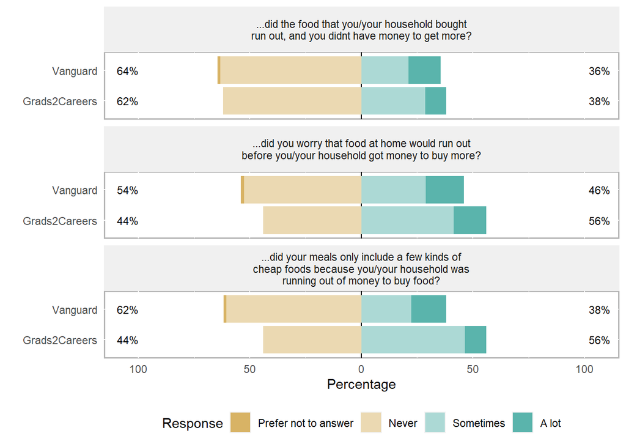

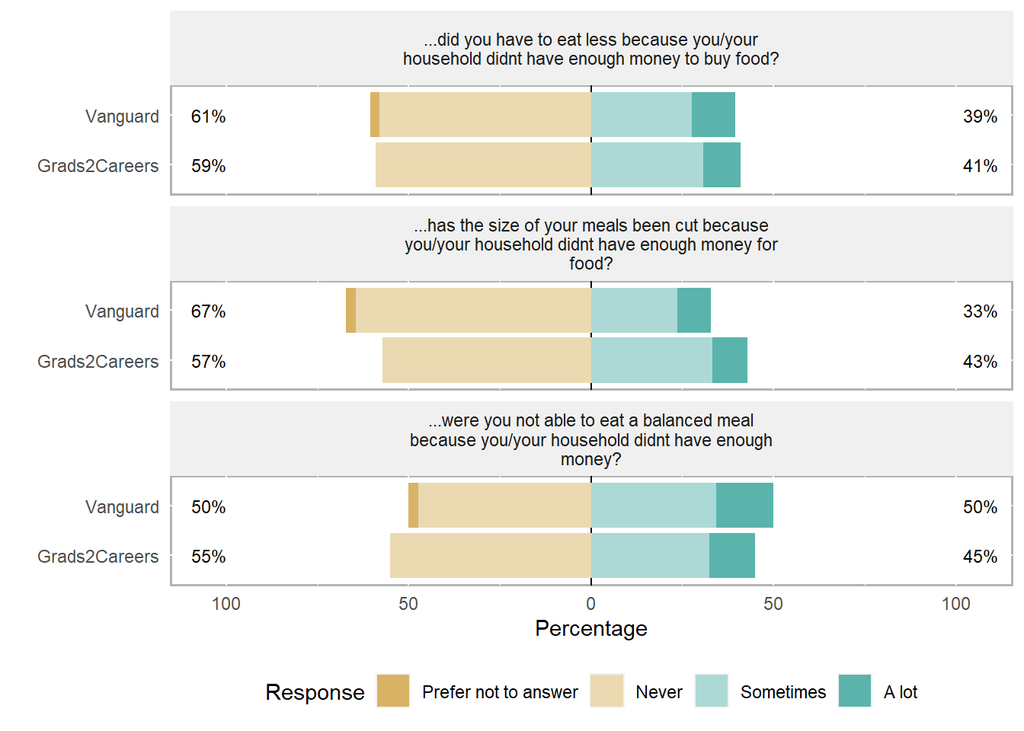

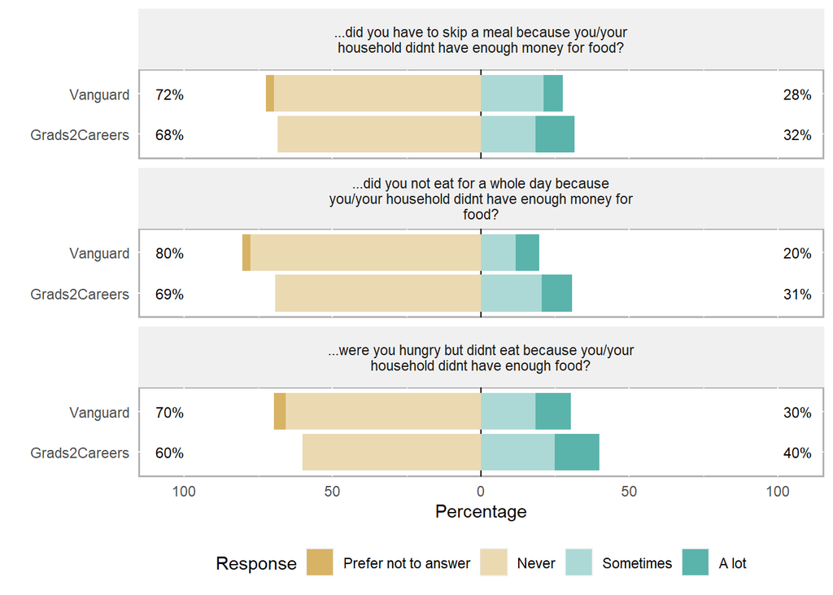

**Histogram of Food Security Scores (total of 9 variables, range:0-18): Vanguard vs. G2C**

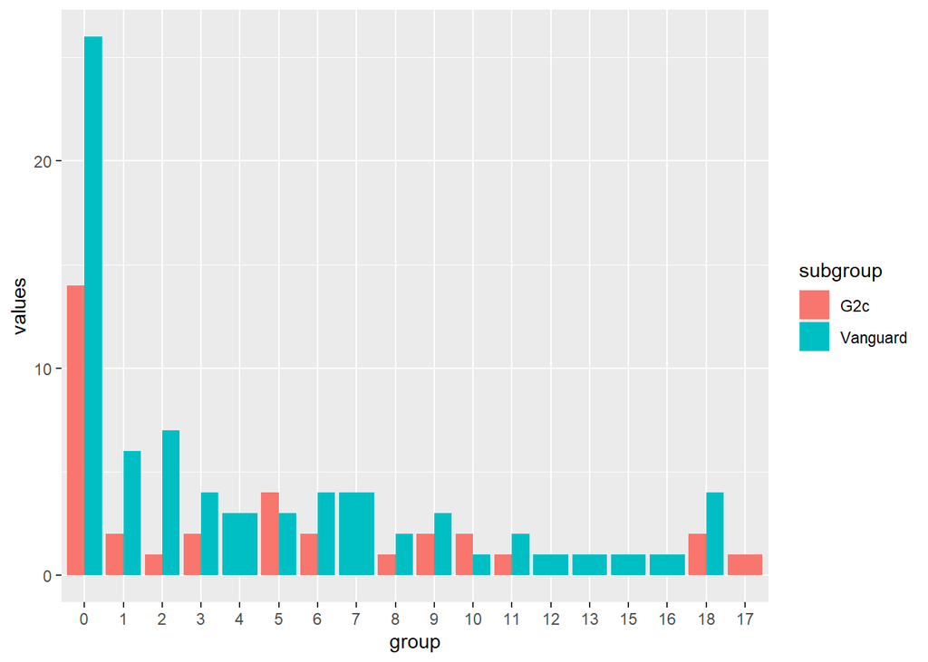

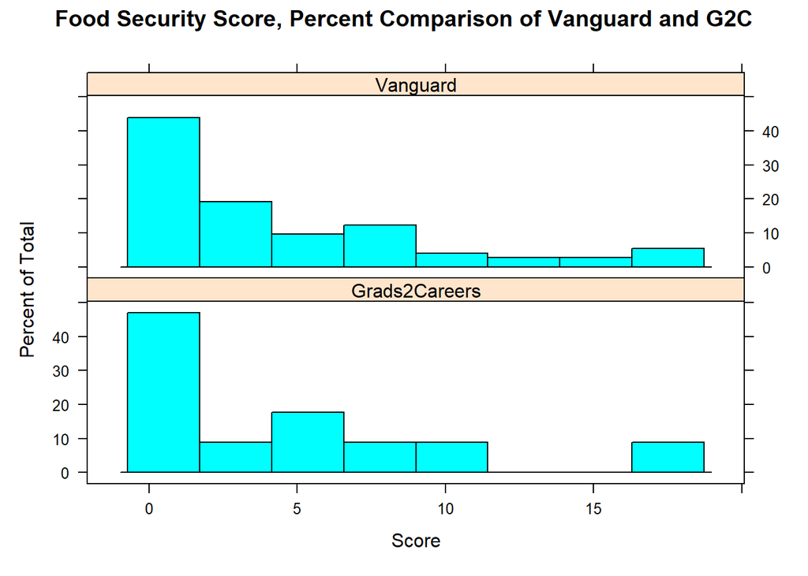

```
##
##  Wilcoxon rank sum test with continuity correction
##
## data:  food_total_merged_age$food_total_no_refused by food_total_merged_age$study
## W = 1228.5, p-value = 0.9342
## alternative hypothesis: true location shift is not equal to 0
```

```
##
##  Welch Two Sample t-test
##
## data:  food_total_merged_age$food_total_no_refused by food_total_merged_age$study
## t = 0.15019, df = 61.798, p-value = 0.8811
## alternative hypothesis: true difference in means between group Grads2Careers and group Vanguard is not equal to 0
## 95 percent confidence interval:
##  -2.083139  2.421576
## sample estimates:
## mean in group Grads2Careers      mean in group Vanguard
##                    4.470588                    4.301370
```

Food Security Score comparison

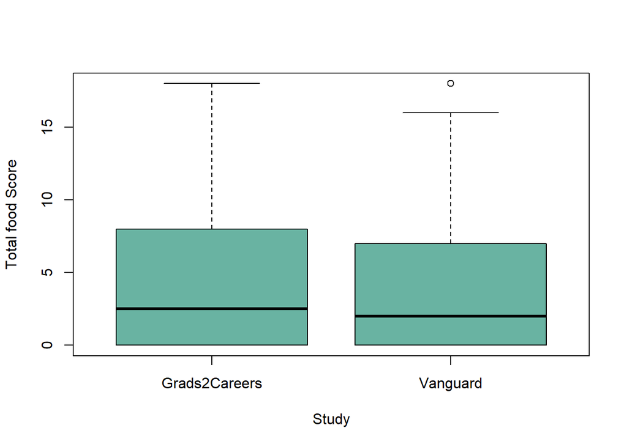

### Anxiety

**Please answer the following questions based on how you felt in the past 7 days.**

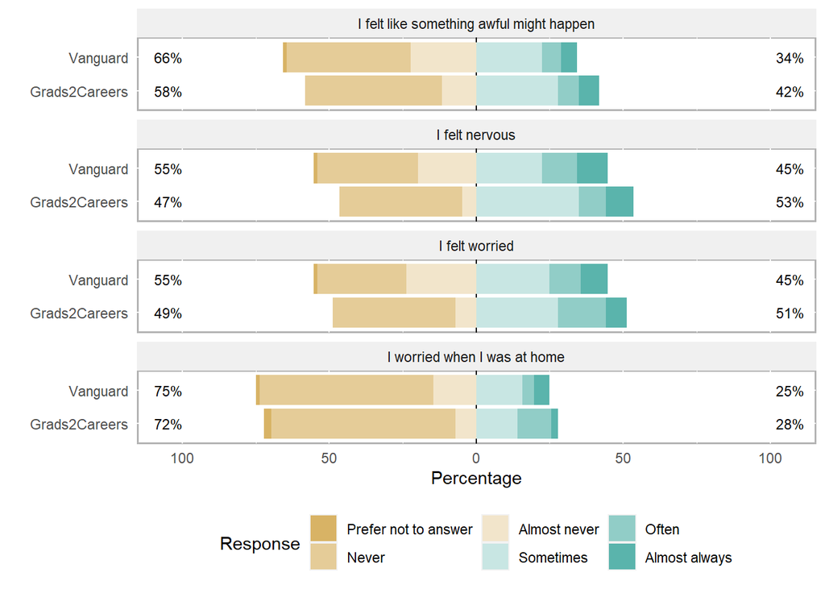

**Histogram of anxiety Scores (total of 4 variables, range:0-16): Vanguard vs. G2C**

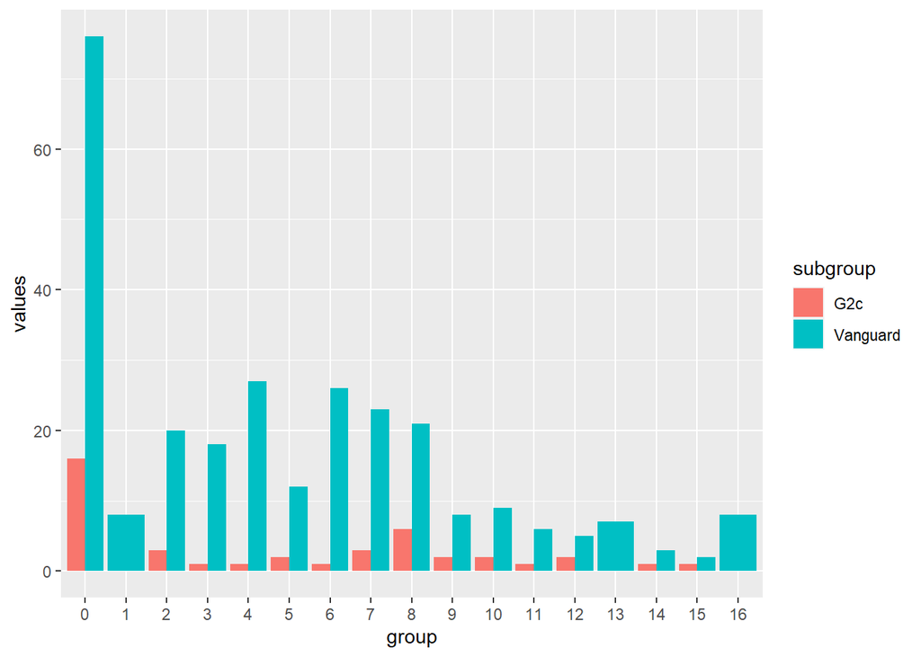

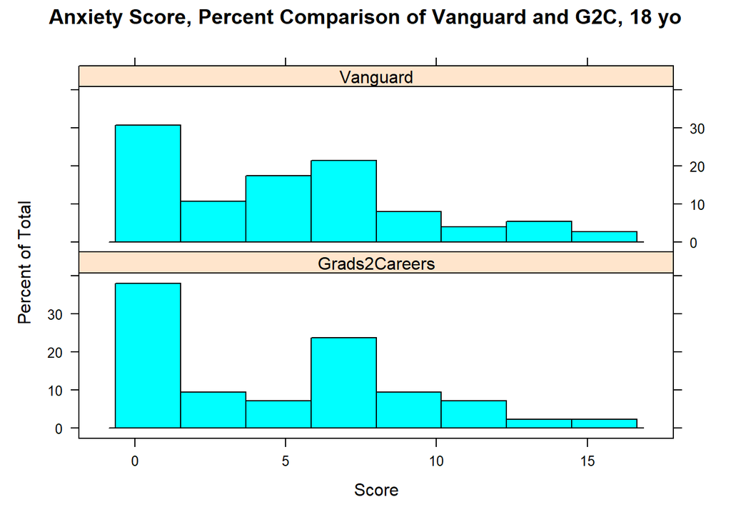

```
##
##  Wilcoxon rank sum test with continuity correction
##
## data:  anxiety_total_merged_age$anxiety_total_no_refused by anxiety_total_merged_age$study
## W = 1563, p-value = 0.9469
## alternative hypothesis: true location shift is not equal to 0
```

```
##
##  Welch Two Sample t-test
##
## data:  anxiety_total_merged_age$anxiety_total_no_refused by anxiety_total_merged_age$study
## t = -0.012946, df = 81.148, p-value = 0.9897
## alternative hypothesis: true difference in means between group Grads2Careers and group Vanguard is not equal to 0
## 95 percent confidence interval:
##  -1.767868  1.745011
## sample estimates:
## mean in group Grads2Careers      mean in group Vanguard
##                    4.761905                    4.773333
```

Anxiety Score comparison

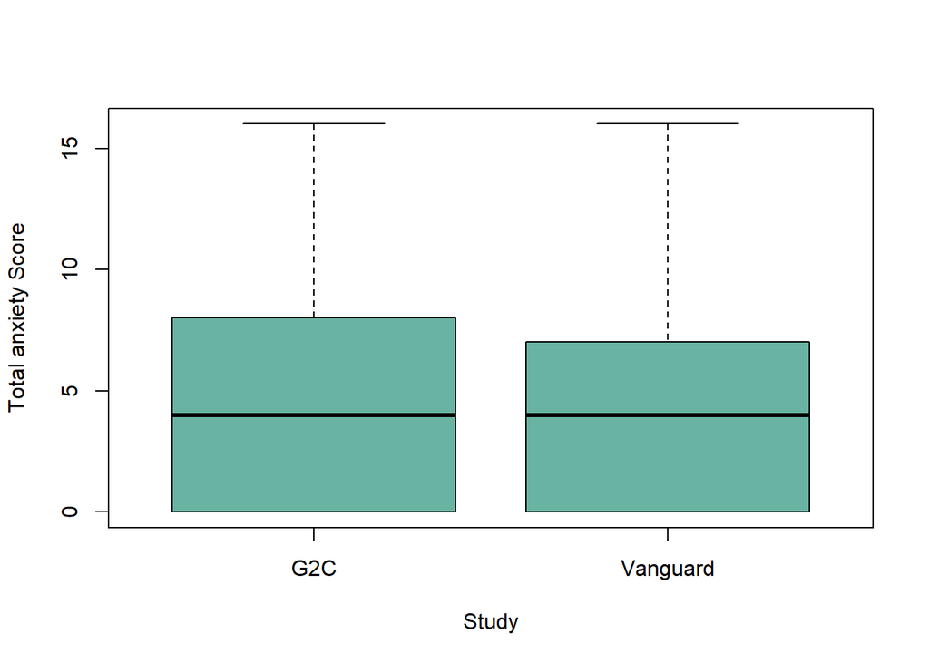

### PTSD/Trauma

**“Below is a list of problems that people sometimes have in response to a very stressful experience. Please read each problem carefully and then circle one of the numbers to the right to indicate how much you have been bothered by that problem in the past 30 days. In the past 30 days, how much were you bothered by:”**

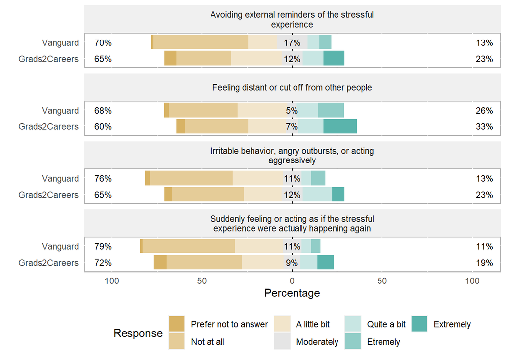

**Histogram of ptsd Scores (total of 4 variables, range:0-16): Vanguard vs. G2C**

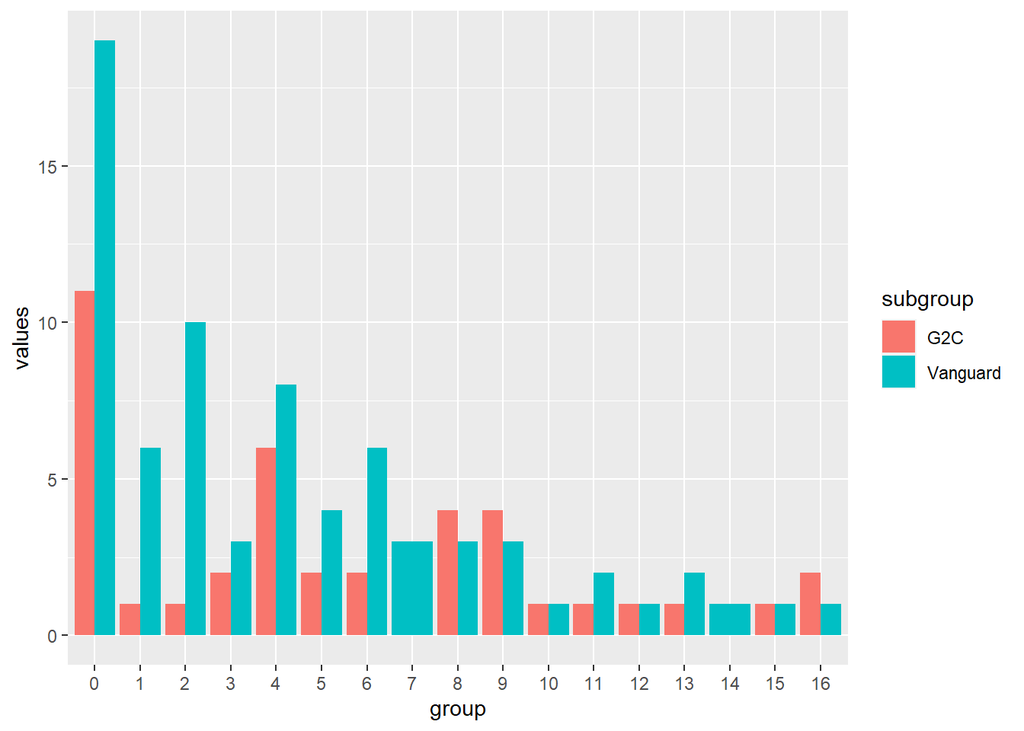

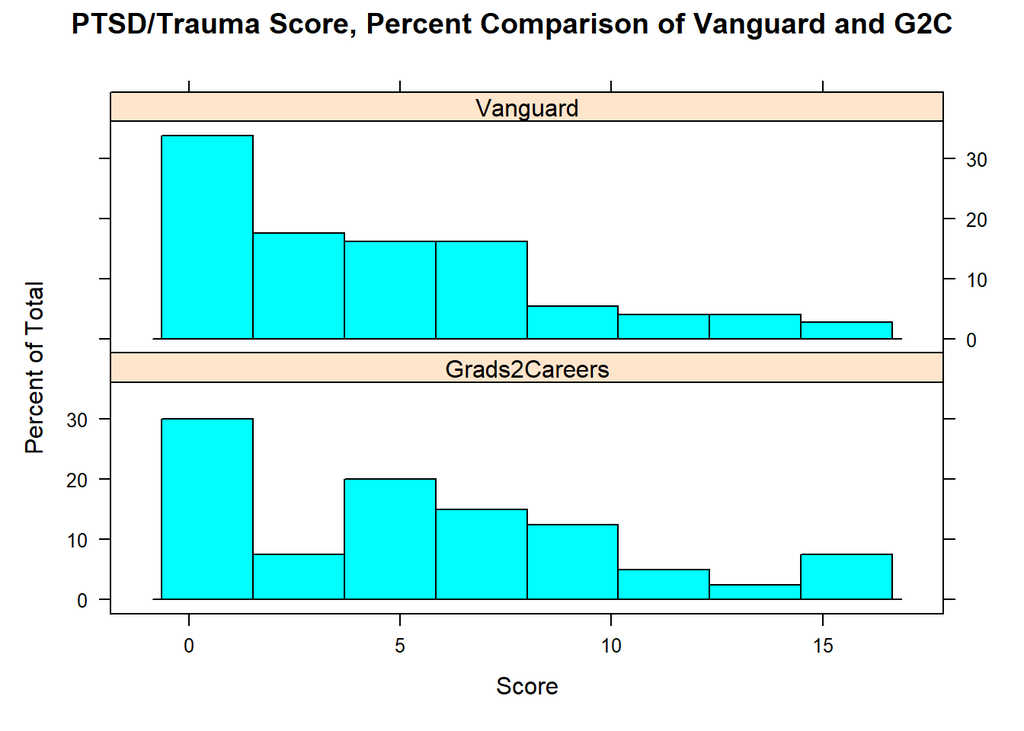

```
##
##  Wilcoxon rank sum test with continuity correction
##
## data:  ptsd_total_merged_age$ptsd_total_no_refused by ptsd_total_merged_age$study
## W = 1670, p-value = 0.2552
## alternative hypothesis: true location shift is not equal to 0
```

```
##
##  Welch Two Sample t-test
##
## data:  ptsd_total_merged_age$ptsd_total_no_refused by ptsd_total_merged_age$study
## t = 1.3257, df = 70.858, p-value = 0.1892
## alternative hypothesis: true difference in means between group Grads2Careers and group Vanguard is not equal to 0
## 95 percent confidence interval:
##  -0.6104501  3.0320717
## sample estimates:
## mean in group Grads2Careers      mean in group Vanguard
##                    5.400000                    4.189189
```

PTSD Score comparison

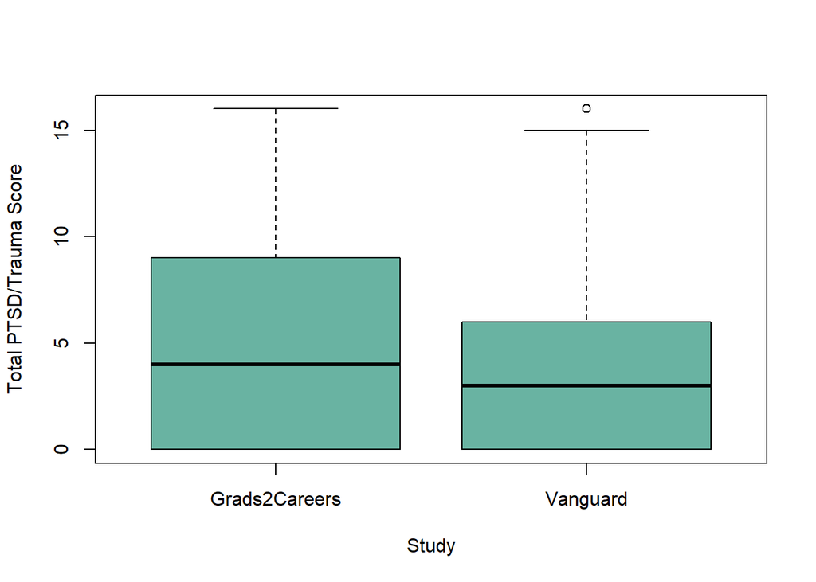

### Depression

**Please answer the following questions based on how you felt in the past 7 days.**

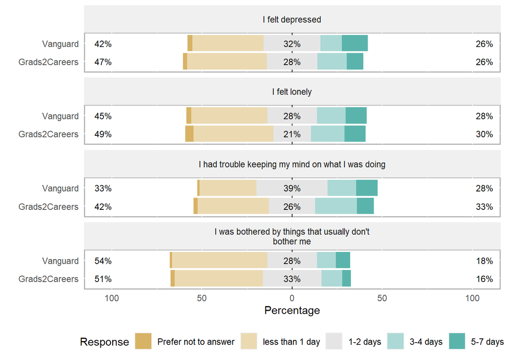

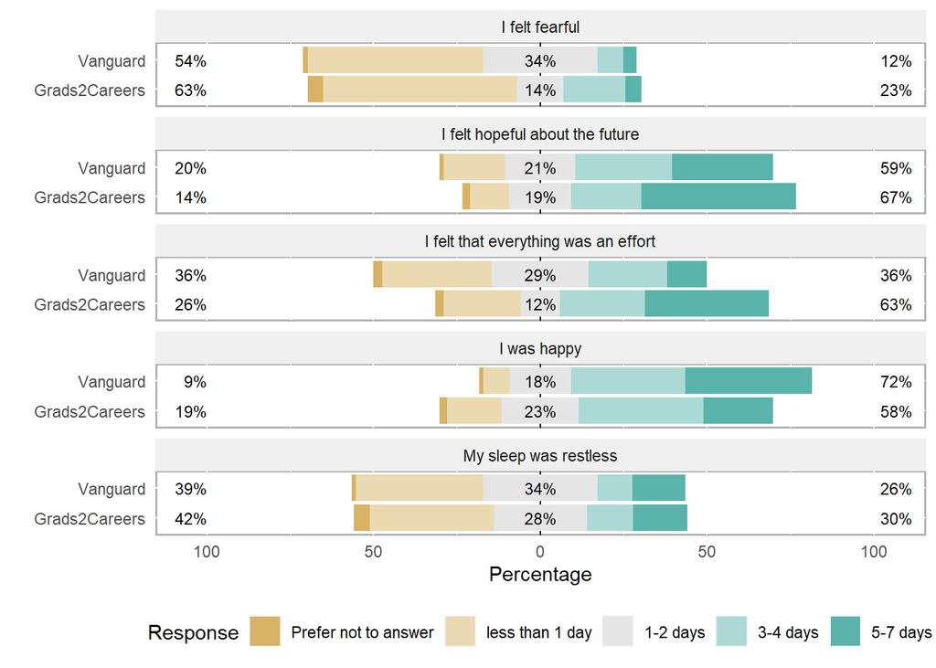

**Histogram of Depression Scores (total of 10 variables, range:0-30): Vanguard vs. G2C**

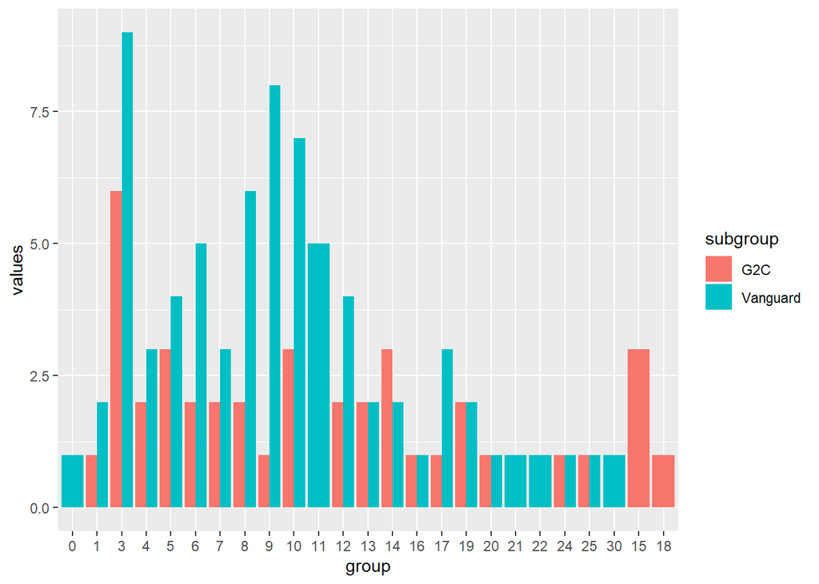

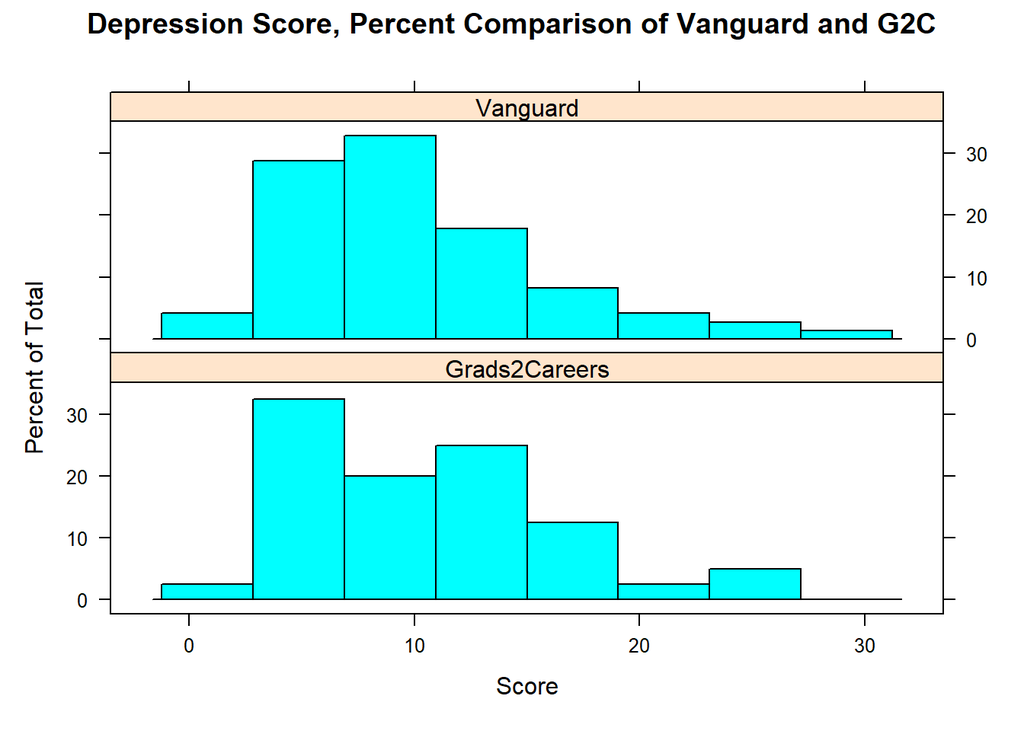

```
##
##  Wilcoxon rank sum test with continuity correction
##
## data:  depression_total_merged_age$depression_total_no_refused by depression_total_merged_age$study
## W = 1570, p-value = 0.5098
## alternative hypothesis: true location shift is not equal to 0
```

```
##
##  Welch Two Sample t-test
##
## data:  depression_total_merged_age$depression_total_no_refused by depression_total_merged_age$study
## t = 0.63604, df = 77.617, p-value = 0.5266
## alternative hypothesis: true difference in means between group Grads2Careers and group Vanguard is not equal to 0
## 95 percent confidence interval:
##  -1.659015  3.216549
## sample estimates:
## mean in group Grads2Careers      mean in group Vanguard
##                   10.450000                    9.671233
```

Depression score comparison

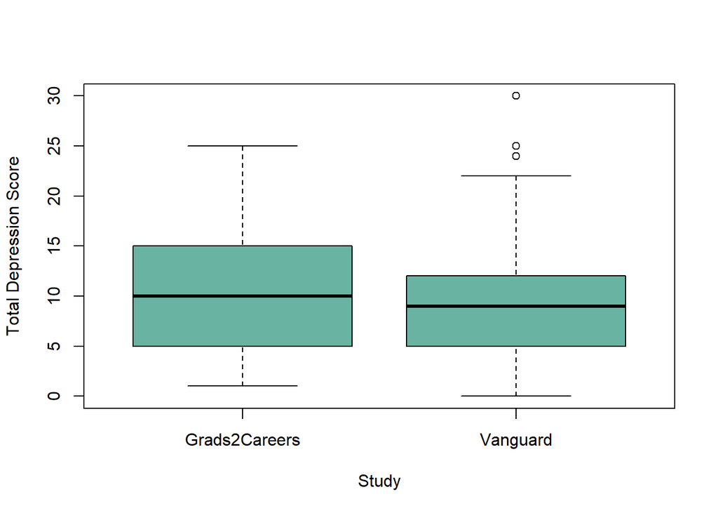

### Cross tabs

Cross Tab - by Study and Food Security Flag, 18yo only

```
##
##
##    Cell Contents
## |-------------------------|
## |                       N |
## |           N / Row Total |
## |-------------------------|
##
##
## Total Observations in Table:  119
##
##
##               | Food Flag, >=2 (max: 18)
##         Study |         0 |         1 | Row Total |
## --------------|-----------|-----------|-----------|
## Grads2Careers |        16 |        27 |        43 |
##               |      0.37 |      0.63 |      0.36 |
## --------------|-----------|-----------|-----------|
##      Vanguard |        32 |        44 |        76 |
##               |      0.42 |      0.58 |      0.64 |
## --------------|-----------|-----------|-----------|
##  Column Total |        48 |        71 |       119 |
## --------------|-----------|-----------|-----------|
##
##
```

Cross Tab - by Study and Anxiety Flag, 18yo only

```
##
##
##    Cell Contents
## |-------------------------|
## |                       N |
## |           N / Row Total |
## |-------------------------|
##
##
## Total Observations in Table:  119
##
##
##               | Anxiety Flag, >=8 (max: 16)
##         Study |         0 |         1 | Row Total |
## --------------|-----------|-----------|-----------|
## Grads2Careers |        27 |        16 |        43 |
##               |      0.63 |      0.37 |      0.36 |
## --------------|-----------|-----------|-----------|
##      Vanguard |        56 |        20 |        76 |
##               |      0.74 |      0.26 |      0.64 |
## --------------|-----------|-----------|-----------|
##  Column Total |        83 |        36 |       119 |
## --------------|-----------|-----------|-----------|
##
##
```

Cross Tab - Study and PTSD Flag, 18yo only

```
##
##
##    Cell Contents
## |-------------------------|
## |                       N |
## |           N / Row Total |
## |-------------------------|
##
##
## Total Observations in Table:  119
##
##
##               | PTSD Flag, >=7 (max: 16)
##         Study |         0 |         1 | Row Total |
## --------------|-----------|-----------|-----------|
## Grads2Careers |        25 |        18 |        43 |
##               |      0.58 |      0.42 |      0.36 |
## --------------|-----------|-----------|-----------|
##      Vanguard |        56 |        20 |        76 |
##               |      0.74 |      0.26 |      0.64 |
## --------------|-----------|-----------|-----------|
##  Column Total |        81 |        38 |       119 |
## --------------|-----------|-----------|-----------|
##
##
```

Cross Tab - Study and Depression Flag, 18yo only

```
##
##
##    Cell Contents
## |-------------------------|
## |                       N |
## |           N / Row Total |
## |-------------------------|
##
##
## Total Observations in Table:  119
##
##
##               | Depression Flag, >=9 (max: 30)
##         Study |         0 |         1 | Row Total |
## --------------|-----------|-----------|-----------|
## Grads2Careers |        18 |        25 |        43 |
##               |      0.42 |      0.58 |      0.36 |
## --------------|-----------|-----------|-----------|
##      Vanguard |        33 |        43 |        76 |
##               |      0.43 |      0.57 |      0.64 |
## --------------|-----------|-----------|-----------|
##  Column Total |        51 |        68 |       119 |
## --------------|-----------|-----------|-----------|
##
##
```